# Size Structure Analysis

Javier Martinez-Arribas (javimartinezarribas@gmail.com)

23 March 2023

```r
library(tidyverse)
library(readxl)
library(rmarkdown)
library(FSA)
```

e carregar os dados…

```r
dbicon <-  DBI::dbConnect(RPostgres::Postgres(),
                          db = Sys.getenv('POSTGRES_DB'),
                          host = Sys.getenv('POSTGRES_HOST'),
                          port = Sys.getenv('POSTGRES_PORT'),
                          user = Sys.getenv('POSTGRES_USER'),
                          password = Sys.getenv('POSTGRES_PASSWORD'))

sql <- 'SELECT * FROM "tblRPN-LF"'
df <- DBI::dbGetQuery(dbicon, sql)
DBI::dbDisconnect(dbicon)
```

```r
#file <- "../../../DATA/output/Calculos_de_RPN-LF_subarea.xlsx"
#df <- read_excel(file)

#str(df)
```

```r
gor <- df %>% filter(Especie == 'GOR' & Ano == 2017)
Summarize(gor$Comprim)
```

```
##           n        mean          sd         min          Q1      median
## 2006.000000   34.261216    8.376702   14.000000   28.000000   34.000000
##          Q3         max
##   41.000000   54.000000
```

Anderson e Neumann (1996) sugeriram intervalos de 1 cm (0.5 in) para peixes que atingem 30 cm (12 in), intervalos de 2 cm (1 in) para peixes que atingem 60 cm (24 in) e intervalos de 5 cm (2 in) para peixes que atingem 150cm (60 in) de comprimento máximo.

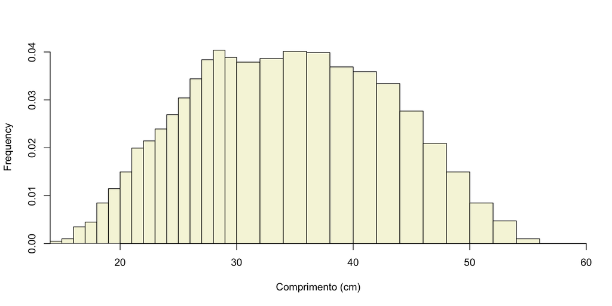

```r
mn <- min(gor$Comprim)
mx <- max(gor$Comprim)
gor.brks = c(seq(mn, 29, 1), seq(30, 60, 2))  # In cm units
hist(~Comprim,data=gor,breaks=gor.brks,main="",xlab="Comprimento (cm)",col="beige")
```

Podemos ver os dados agrupados por diferentes variáveis, como por “Área”:

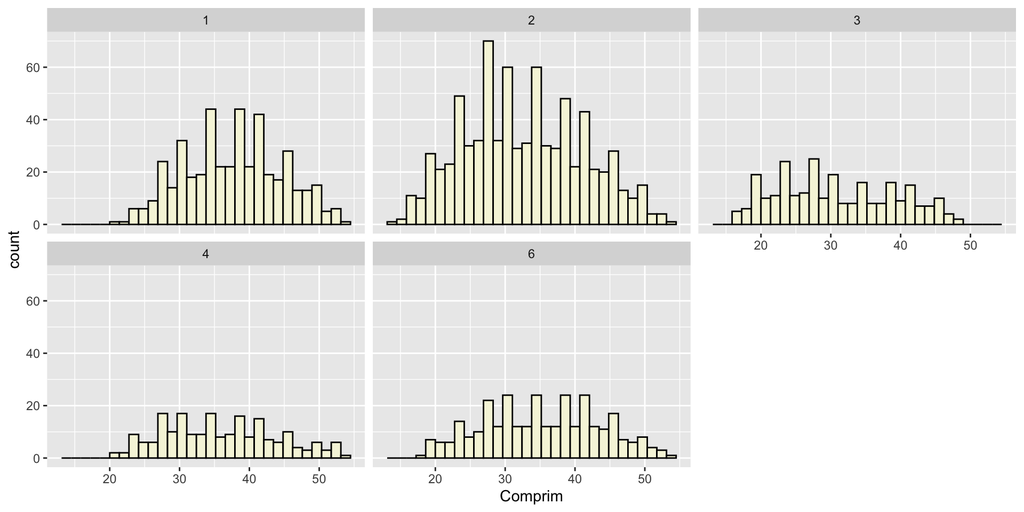

```r
ggplot(gor, aes(Comprim, group = Area)) +
  geom_histogram(fill='beige',color='black') +
  facet_wrap(~ Area)
```

o Subárea:

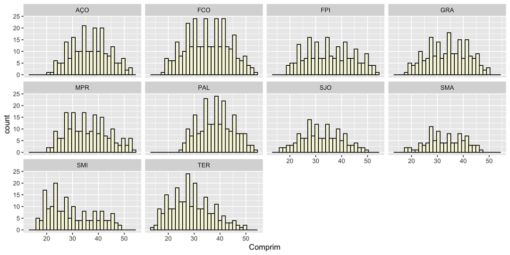

```r
ggplot(gor, aes(Comprim, group = Subarea)) +
  geom_histogram(fill='beige',color='black') +
  facet_wrap(~ Subarea)
```

ou Estrato:

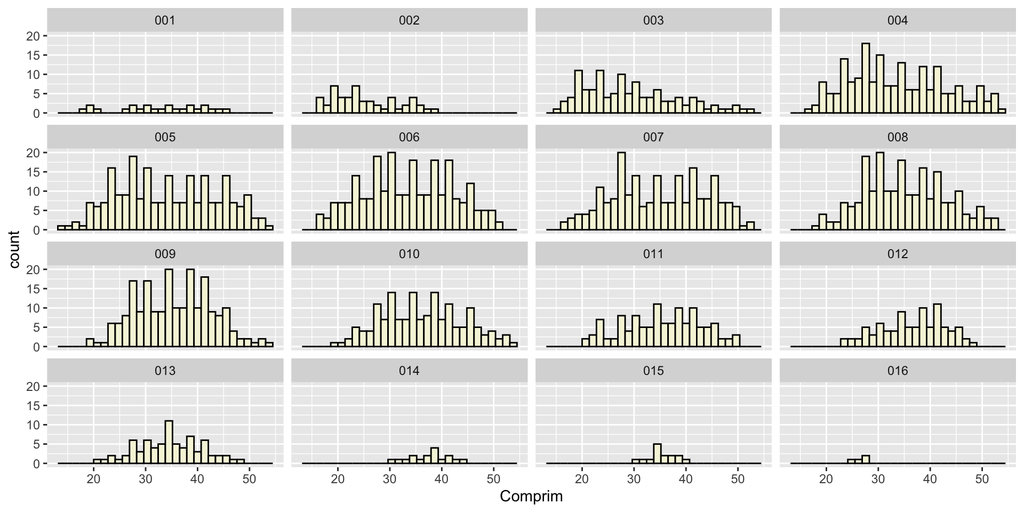

```r
ggplot(gor, aes(Comprim, group = Estrato)) +
  geom_histogram(fill='beige',color='black') +
  facet_wrap(~ Estrato)
```

## Proportional Size Distribution

Gabelhouse (1984b) introduziu o sistema de categorização de “comprimento de cinco células” que define comprimentos para os chamados indivíduos de tamanho “stock”, “quality”, “preferred”, “memorable” e “tropy” de uma grande variedade de espécies.

Anderson e Weithman (1978) escolheram comprimentos equivalente a:

- Stock = 20-26% de comprimento recorde.
- Quality = 36-41% de comprimento recorde.
- Preferred = 45-55% de comprimento recorde.
- Memorable = 59-64% de comprimento recorde.
- Trophy = 74-80% de comprimento recorde.

Vejamos essa categorização como está representada na função de distribuição da variável Comprimento:

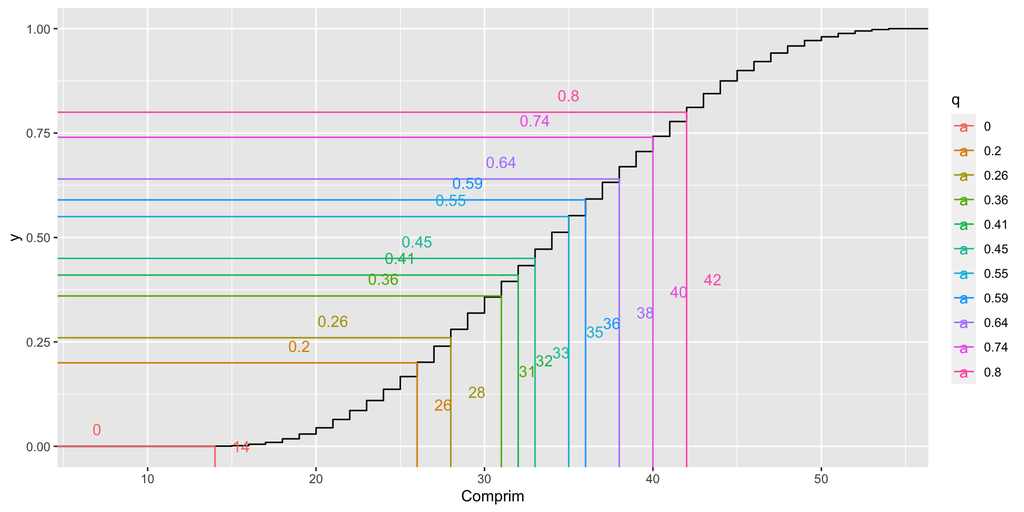

```r
# Quantiles
q <- c(0, 0.20, 0.26, 0.36, 0.41, 0.45, 0.55, 0.59, 0.64, 0.74, 0.8)

# data.frame for quantiles
qdf <- data.frame(
  q = factor(q),
  x = c(rep(-Inf, length(q)), rep(quantile(gor$Comprim, q), 2)),
  y = c(rep(q, 2), rep(-Inf, length(q)))
)

ggplot(gor, aes(Comprim)) +
  stat_ecdf() +
  # Line segments to/from the ecdf line
  geom_path(
    data = qdf,
    aes(x = x, y = y, colour = q),
    linetype = 1
  ) +
  # Labels at x
  geom_text(
    data = subset(qdf, is.finite(x) & is.finite(y)),
    aes(x = x, y = 0.5 * y, label = x, colour = q),
    hjust = -1
  ) +
  # Labels at y
  geom_text(
    data = subset(qdf, is.finite(x) & is.finite(y)),
    aes(x - 0.5 * min(x), y = y, label = y, colour = q),
    vjust = -1
  )
```

Os percentis propostos por Anderson e Weithman correspondem aos comprimentos:

- Stock = 26-28 cm of record length
- Quality = 31-32 cm of record length
- Preferred = 33-35 cm of record length
- Memorable = 36-38 cm of record length
- Trophy = 40-42 cm of record length

Os dados de frequência de comprimento podem ser resumidos em algumas estatísticas úteis chamadas distribuição de tamanho proporcional índices (PSD-X; Guy et al. 2007).

Um índice PSD-X é definido como a proporção de peixes do tamanho “stock” que também são maiores do que alguma outra categoria de tamanho maior. Especificamente:

$$PSD-X = \frac{Número\;de\;peixes \ge
comprimento\;especificado}{Número\;de\;peixes \ge
comprimento\;stock}$$
O X na fórmula é substituído por uma letra ou descritor específico para a especificação de comprimento no numerador.

O cálculo do PSD-X é simplificado no R através do uso de várias funções no pacote FSA, mas não disponível para todas as espécies de peixes.

Por padrão, as quebras de intervalo são inclusivas (por exemplo, um peixe de 8 cm será incluído no intervalo de 6-8 cm em vez do intervalo de 8-10 cm). Isso não é o que a maioria dos biólogos pesqueiros deseja, então vamos mudar as quebras de intervalo para deixá-las inclusivas em seu lugar.

Por isso vamos criar um dataframe com os dados necessários para calcular essas funções para outras espécies que não aparecem no pacote:

```r
interval_table <- table(cut(gor$Comprim,unname(quantile(gor$Comprim, q)),include.lowest = T, right = F))
inter <- as.data.frame((interval_table))
inter <- inter %>% mutate(csum = cumsum(Freq),
                          rcsum = rcumsum(Freq),
                          min = unname(quantile(gor$Comprim, q))[1:nrow(inter)],
                          labels = c('zero','stock','stock','quality','quality','preferred',
                               'preferred','memorable','memorable','trophy'))

psd <- inter %>% group_by(labels) %>% summarise(Csum = min(csum), Rcsum = max(rcsum),Min = min(min))
psd <- merge(psd, inter, by.x = c("labels","Min"),
        by.y = c("labels","min"), all.x = TRUE, all.y = FALSE) %>%
        select(-Var1) %>%
        arrange(Min)
```

E então encontramos os diferentes índices PSD-X e seus intervalos de confiança de 95% com a ajuda da função binCI():

```r
#PSD-Q
psd_q <- round(psd[psd$labels=='quality','Rcsum']/psd[psd$labels=='stock','Rcsum'] *100,5)
LCI_q <- unname(binCI(as.numeric(psd[psd$labels=='quality','Rcsum']),
                as.numeric(psd[psd$labels=='stock','Rcsum']))*100 )[1,1]
UCI_q <- unname(binCI(as.numeric(psd[psd$labels=='quality','Rcsum']),
                as.numeric(psd[psd$labels=='stock','Rcsum']))*100 )[1,2]
#PSD-P
psd_p <- round(psd[psd$labels=='preferred','Rcsum']/psd[psd$labels=='stock','Rcsum'] *100,5)
LCI_p <- unname(binCI(as.numeric(psd[psd$labels=='preferred','Rcsum']),
                as.numeric(psd[psd$labels=='stock','Rcsum']))*100 )[1,1]
UCI_p <- unname(binCI(as.numeric(psd[psd$labels=='preferred','Rcsum']),
                as.numeric(psd[psd$labels=='stock','Rcsum']))*100 )[1,2]
#PSD-M
psd_m <- round(psd[psd$labels=='memorable','Rcsum']/psd[psd$labels=='stock','Rcsum'] *100,5)
LCI_m <- unname(binCI(as.numeric(psd[psd$labels=='memorable','Rcsum']),
                as.numeric(psd[psd$labels=='stock','Rcsum']))*100 )[1,1]
UCI_m <- unname(binCI(as.numeric(psd[psd$labels=='memorable','Rcsum']),
                as.numeric(psd[psd$labels=='stock','Rcsum']))*100 )[1,2]
#PSD-T
psd_t <- round(psd[psd$labels=='trophy','Rcsum']/psd[psd$labels=='stock','Rcsum'] *100,5)
LCI_t <- unname(binCI(as.numeric(psd[psd$labels=='trophy','Rcsum']),
                as.numeric(psd[psd$labels=='stock','Rcsum']))*100 )[1,1]
UCI_t <- unname(binCI(as.numeric(psd[psd$labels=='trophy','Rcsum']),
                as.numeric(psd[psd$labels=='stock','Rcsum']))*100 )[1,2]


lbls <- c("PSD-Q","PSD-P","PSD-M","PSD-T")
vals <- c(as.numeric(psd_q), as.numeric(psd_p),as.numeric(psd_m),as.numeric(psd_t))
lcis_95 <- c(LCI_q,LCI_p,LCI_m,LCI_t)
ucis_95 <- c(UCI_q,UCI_p,UCI_m,UCI_t)

(psd_df <- data_frame(lbls,vals,lcis_95,ucis_95))
```

```
## # A tibble: 4 × 4
##   lbls   vals lcis_95 ucis_95
##   <chr> <dbl>   <dbl>   <dbl>
## 1 PSD-Q  70.5    67.9    72.9
## 2 PSD-P  58.8    56.0    61.5
## 3 PSD-M  40.2    37.5    42.9
## 4 PSD-T  16.4    14.4    18.5
```

Como um aviso para dizer que os cálculos de PSD não precisam ser restritos apenas aos comprimentos na categorização de comprimento de cinco células sistema.

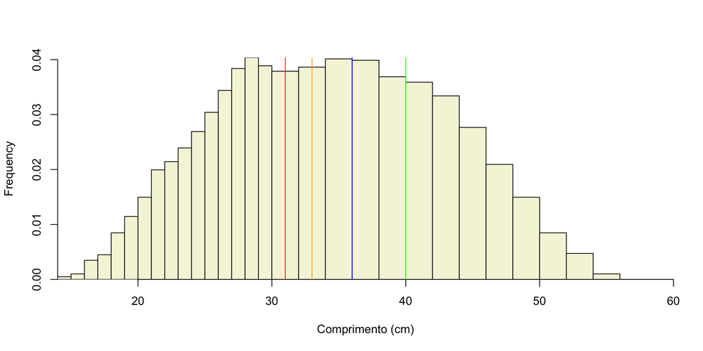

```r
hist(~Comprim,data=gor,breaks=gor.brks,main="",xlab="Comprimento (cm)",col="beige")
abline(v=31,col='red')
abline(v=33,col='orange')
abline(v=36,col='blue')
abline(v=40,col='green')
```

Como regra geral, diz-se que uma população de peixes está “em equilíbrio” se o valor de PSD estiver entre 30 e 70.

Diferentes intervalos foram propostos para diferentes espécies. A ideia por trás desses alvos intervalos é que, se o valor de PSD for muito baixo, haverá poucos peixes grandes na população, enquanto um valor muito PSD grande indica que há poucos peixes pequenos na população.

Esses intervalos-alvo devem ser usados com cuidado, porém, como um PSD “em equilíbrio” pode ser produzido a partir de uma ampla variedade de estruturas de tamanho. O PSD é um resumo útil, mas não deve ser usado sem também examinar os histogramas de frequência de comprimento.

## Test Kolmogorov–Smirnov

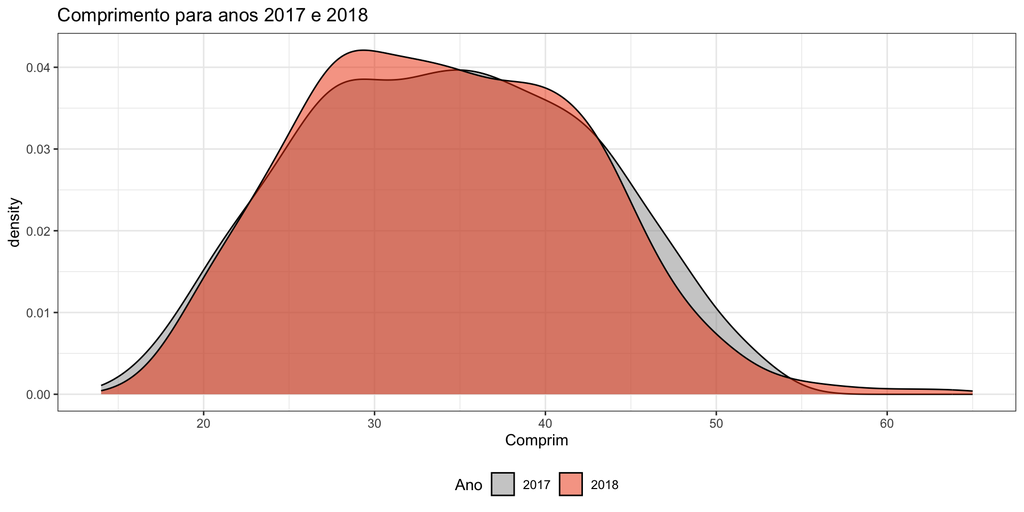

```r
df_ks <- df %>%
          filter(Ano %in% c(2017, 2018) & Especie == 'GOR') %>%
          mutate(Ano = as.factor(Ano)) %>%
          select(Ano, Comprim)
df_ks %>%
    ggplot(aes(x = Comprim, fill = Ano)) +
    geom_density(alpha = 0.5) +
    scale_fill_manual(values = c("gray60", "orangered2")) +
    labs(title = "Comprimento para anos 2017 e 2018",
         #subtitle = "Escala logarítmica, 738 observaciones por año",
         fill = "Ano") +
    theme_bw() +
    theme(legend.position = "bottom")
```

Cálculo da função de distribuição cumulativa empírica da amostra

```r
ecdf_2017 <- ecdf(df_ks %>% filter(Ano == 2017) %>% pull(Comprim))
ecdf_2018 <- ecdf(df_ks %>% filter(Ano == 2018) %>% pull(Comprim))

#A probabilidade cumulativa de cada valor observado de comprimento é calculada
#com cada uma das funções ecdf.
grid_comprim <- unique(df_ks %>% pull(Comprim))
prob_cum_ecdf_2017 <- ecdf_2017(v = grid_comprim)
prob_cum_ecdf_2018 <- ecdf_2018(v = grid_comprim)
```

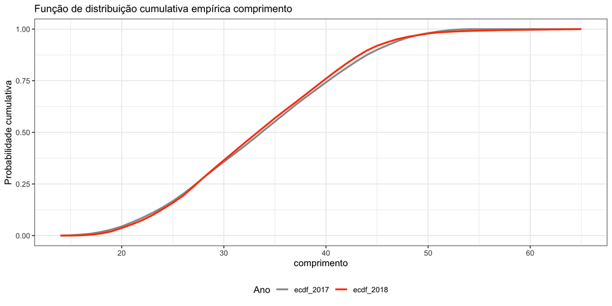

```r
# Vincule os valores calculados em um dataframe.
df_ecdf <- data.frame(
            comprimento = grid_comprim,
            ecdf_2017 = prob_cum_ecdf_2017,
            ecdf_2018 = prob_cum_ecdf_2018
           ) %>%
          pivot_longer(
            cols = c(ecdf_2017, ecdf_2018),
            names_to = "ano",
            values_to = "ecdf"
          )

grafico_ecdf <- ggplot(data = df_ecdf,
                       aes(x = comprimento, y = ecdf, color = ano)) +
                geom_line(size = 1) +
                scale_color_manual(values = c("gray60", "orangered1")) +
                labs(
                 title = "Função de distribuição cumulativa empírica comprimento",
                 color = "Ano",
                 y = "Probabilidade cumulativa"
                ) +
                theme_bw() +
                theme(legend.position = "bottom",
                      plot.title = element_text(size = 12))

grafico_ecdf
```

Opção dois para desenhar o gráfico acima

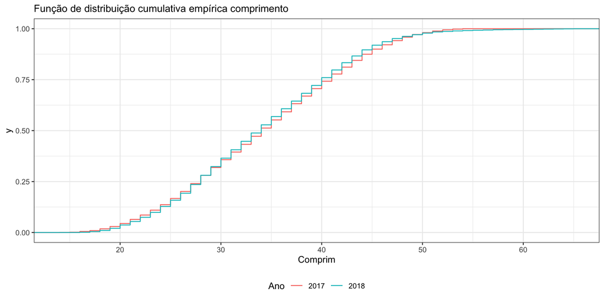

```r
df_ks %>%
    ggplot(aes(x = Comprim, color = Ano)) +
    stat_ecdf(geom = "step") +
    labs(title = "Função de distribuição cumulativa empírica comprimento",
         color = "Ano") +
    theme_bw() +
    theme(legend.position = "bottom",
          plot.title = element_text(size=12))
```

### Cálculo da distância Kolmogorov-Smirnov

```r
# Calcule a diferença absoluta entre as probabilidades cumulativas de cada
# função.
abs_dif <-  abs(prob_cum_ecdf_2017 - prob_cum_ecdf_2018)

# A distância Kolmogorov–Smirnov é o máximo das distâncias absolutas.
distancia_ks <- max(abs_dif)
paste("Distância Kolmogorov–Smirnov:", distancia_ks)
```

```
## [1] "Distância Kolmogorov–Smirnov: 0.0218605799406364"
```

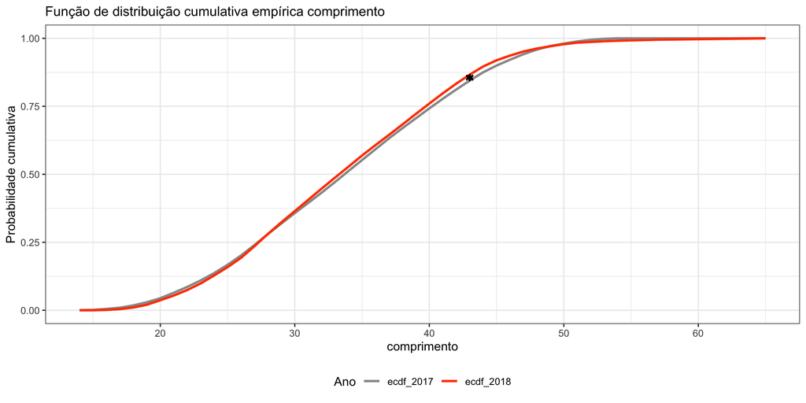

```r
indice_ks <- which.max(abs_dif)

grafico_ecdf +
  geom_segment(aes(
                x = grid_comprim[indice_ks],
                xend = grid_comprim[indice_ks],
                y = prob_cum_ecdf_2017[indice_ks],
                yend = prob_cum_ecdf_2018[indice_ks]
               ),
               arrow = arrow(ends = "both", length = unit(0.2,"cm")),
               color = "black")
```

A função ks.test() do pacote stats calcula, como parte do teste, a distância Kolmogorov–Smirnov. Verifica-se, a título de validação, que ambos os valores coincidem.

```r
test <- ks.test(
        x = df_ks %>% filter(Ano == 2017) %>% pull(Comprim),
        y = df_ks %>% filter(Ano == 2018) %>% pull(Comprim)
      )
test$statistic
```

```
##          D
## 0.02186058
```

Para a estatística de Kolmogorov–Smirnov existem dois tipos de solução:

Através de um teste de reamostragem: consiste em simular, por meio de permutações ou bootstrapping, as distâncias Kolmogorov-Smirnov que seriam obtidas se ambas as amostras viessem da mesma distribuição. Uma vez obtidas as simulações, calcula-se a porcentagem de distâncias iguais ou maiores que a observada.

```r
#Bootstraping
set.seed(123)
test_ks_boot <- Matching::ks.boot(
                  Tr = df_ks %>% filter(Ano == 2017) %>% pull(Comprim),
                  Co = df_ks %>% filter(Ano == 2018) %>% pull(Comprim),
                  alternative = "two.sided",
                  nboots = 10000
                )

test_ks_boot$ks.boot.pvalue
```

```
## [1] 0.6102
```

```r
#Analítica
test_ks <- ks.test(
        x = df_ks %>% filter(Ano == 2017) %>% pull(Comprim),
        y = df_ks %>% filter(Ano == 2018) %>% pull(Comprim)
      )
test_ks
```

```
##
##  Two-sample Kolmogorov-Smirnov test
##
## data:  df_ks %>% filter(Ano == 2017) %>% pull(Comprim) and df_ks %>% filter(Ano == 2018) %>% pull(Comprim)
## D = 0.021861, p-value = 0.7938
## alternative hypothesis: two-sided
```

Em ambos os casos, não há evidências suficientes para considerar que a distribuição de comprimentos variou de um ano para o outro.